# Q2_2014_Ridership_Analysis

## **CitiBike NYC Analysis**

The major focus of this analysis is the period of June, 2014. For this period a Tableau package was created to explore demographics of gender and age. An in-depth worksheet looks at the time of day ride for each station for each day of the month. Top 10 start stations and bottom 10 stations are visualized in separate sheets. Finally, the system of start stations is visualized in a map. The start station markers are sized and colored by the number of starts to help users find the station by address. The map may be filtered by day of the week. A different pattern emerges for the weekdays than that of the weekends. One key station for the weekdays is located at 8th Ave and W. 31st St. This station is in the near proximity of Penn Station (Amtrak), Madison Square Garden, and the starting spot for many a tour. Similarly, the start station located on E42nd and Vanderbilt is near Grand Central Terminal (MTA Metro North Railway).

The station located at W 21st and 6th Ave. is near the Empire State Building and Radio City Music Hall is another high count station on the weekends.

In addition to the more granular Tableau analysis discussed above, the ridership data for the periods of Q2 2014 and Q2 2019 is analyzed using Pandas in a Jupyter Notebook. Overall ridership for Q2 2014 in terms of recorded trips was calculated as well as the in-quarter percentage growth.

**Ridership:** 2,694,600 recorded trips in 2014 Q2. Percent change for the quarter: 36.433%.

To look at the changing *proportions* of annual *subscribers:24 hour passes*, Q2 2014 was compared to the same  
period for 2019:

- In 2014 Q2, the proportion of annual subscribers to 24 hours passes was 1.037:1.
- In 2019 Q2, the proportion of annual subscribers to 24 hours passes was 0.86:1.

The percentage growth from 2014 to 2019 for annual members was 176.57%; the percentage growth for 24 Hours Passes was 232.23%.

```python
# importing pandas module
import pandas as pd
import numpy as np
import matplotlib.pyplot as plt

np.random.seed(444)
```

```python
# reading csv file from url
data = pd.read_csv("/Users/rebeccajbooth/Documents/newcitidata/q2ridership.csv")
data.head()
```

|  | Date | Trips over the past 24-hours (midnight to 11:59pm) | Cumulative trips (since launch): | Miles traveled today (midnight to 11:59 pm) | Miles traveled to date: | Total Annual Memberships Sold | Annual Member Sign-Ups (midnight to 11:59 pm) | 24-Hour Passes Purchased (midnight to 11:59 pm) | 7-Day Passes Purchased (midnight to 11:59 pm) |
| --- | --- | --- | --- | --- | --- | --- | --- | --- | --- |
| 0 | 4/1/2014 | 26163 | 7395956 | 40.978 | 12,758,196 | 100337 | 174 | 475 | 67 |
| 1 | 4/2/2014 | 24299 | 7420255 | 35.540 | 12,793,736 | 100511 | 118 | 237 | 33 |
| 2 | 4/3/2014 | 28379 | 7448634 | 44.649 | 12,838,385 | 100629 | 171 | 596 | 63 |
| 3 | 4/4/2014 | 13593 | 7462227 | 17.644 | 12,856,030 | 100800 | 92 | 103 | 10 |
| 4 | 4/5/2014 | 20333 | 7482560 | 36.797 | 12,892,827 | 100892 | 127 | 1221 | 42 |

```python
data['Date'].count()
```

```
91
```

# How many trips have been recorded total during 2014?

# 2,694,600

Methodology:

The number of trips was calculated in variable 'ridership_growth' by subtracting the first day of the period, 'Cumulative trips (since launch)'from the last day of the period, 'Cumulative trips (since launch)' *qrtcum_finish = data["Cumulative trips (since launch):"].max() less* qrtcum_start = data["Cumulative trips (since launch):"].min()

```python
qrtcum_finish = data["Cumulative trips (since launch):"].max()
```

```python
qrtcum_start = data["Cumulative trips (since launch):"].min()
```

```python
ridership_growth = qrtcum_finish - qrtcum_start
ridership_growth
```

```
2694600
```

# For 2014, by what percentage has total ridership grown?

# 36.43%

```python
percent_ridership_growth = (ridership_growth / qrtcum_start) * 100
percent_ridership_growth
```

```
36.433423887324366
```

# How has the proportion of short-term customers and annual subscribers changed?

2014 Q2: Annual subscribers : 24 hour passes = 1.037 : 1

2019 Q2: Annual subscribers : 24 hours passes = 0.86 : 1

Methodology:

- Compared 2nd Quarter 2014 to 2nd Quarter 2019
- Max Total Annual Members (All Time)
- 24-Hour Passes Purchased (midnight to 11:59 pm)

```python
qrtcum_annmembers = data["Total Annual Memberships Sold"].max()
onedaysu_cum = data['24-Hour Passes Purchased (midnight to 11:59 pm)'].sum()

qrtcum_annmembers
```

```
114260
```

```python
onedaysu_cum
```

```
110170
```

```python
proportion1 = qrtcum_annmembers / onedaysu_cum
proportion1
```

```
1.0371244440410274
```

# How has membership for 24 hour passes and Annual Memberships changed from 2014 to 2019 [Q2]?

*Annual Memberships increased by 176.57%;* Twenty-four Hours Passes increased by 232.23%.

```python
data1 = pd.read_csv("/Users/rebeccajbooth/Documents/newcitidata/data-MM5kM.csv")
data1.head()
```

|  | Date | Trips over the past 24-hours (midnight to 11:59pm) | Miles traveled today (midnight to 11:59 pm) | Total Annual Members (All Time) | 24-Hour Passes Purchased (midnight to 11:59 pm) | 3-Day Passes Purchased (midnight to 11:59 pm) | Column 1 |
| --- | --- | --- | --- | --- | --- | --- | --- |
| 0 | 4/1/19 | 51399 | 75072 | 303223 | 1466 | 76 | undefined |
| 1 | 4/2/19 | 57903 | 83399 | 303386 | 1483 | 73 | undefined |
| 2 | 4/3/19 | 67924 | 108780 | 303552 | 3013 | 79 | undefined |
| 3 | 4/4/19 | 66403 | 104268 | 303699 | 2633 | 87 | undefined |
| 4 | 4/5/19 | 34470 | 46930 | 303766 | 812 | 46 | undefined |

```python
qrtcum_annmembers1 = data1["Total Annual Members (All Time)"].max()
onedaysu_cum1 = data1['24-Hour Passes Purchased (midnight to 11:59 pm)'].sum()
```

```python
onedaysu_cum1
```

```
366017
```

```python
qrtcum_annmembers1
```

```
316007
```

```python
annmembers_growth = qrtcum_annmembers1 - qrtcum_annmembers
annmembers_growth
```

```
201747
```

```python
percent_annmembers_growth = (annmembers_growth / qrtcum_annmembers) * 100
percent_annmembers_growth
```

```
176.56835287939788
```

```python
onedaypass_growth = onedaysu_cum1 - onedaysu_cum
onedaypass_growth
```

```
255847
```

```python
percent_onedaypass_growth = (onedaypass_growth / onedaysu_cum) * 100
percent_onedaypass_growth
```

```
232.22928201869837
```

```python
proportion2 = qrtcum_annmembers1 / onedaysu_cum1
proportion2
```

```
0.8633670020791384
```

```python
td_data = pd.read_csv("/Users/rebeccajbooth/Documents/tableaunycbike/CitiBiketrips_June06.csv")
td_data.head()
```

|  | tripduration | starttime | stoptime | start.station.id | start.station.name | start.station.latitude | start.station.longitude | end.station.id | end.station.name | end.station.latitude | end.station.longitude | bikeid | usertype | birth_year | gender | LatLng | State | City |
| --- | --- | --- | --- | --- | --- | --- | --- | --- | --- | --- | --- | --- | --- | --- | --- | --- | --- | --- |
| 0 | 917 | 6/2/14 17:38 | 6/2/14 17:53 | 259 | South St & Whitehall St | 40.701221 | -74.012342 | 349 | Rivington St & Ridge St | 40.718502 | -73.983299 | 15809 | Subscriber | 1899 | 1 | 40.701221 -74.012342 | New York | New York |
| 1 | 1284 | 6/2/14 20:10 | 6/2/14 20:32 | 349 | Rivington St & Ridge St | 40.718502 | -73.983299 | 259 | South St & Whitehall St | 40.701221 | -74.012342 | 19449 | Subscriber | 1899 | 1 | 40.718502 -73.983299 | New York | New York |
| 2 | 629 | 6/3/14 16:43 | 6/3/14 16:53 | 259 | South St & Whitehall St | 40.701221 | -74.012342 | 2009 | Catherine St & Monroe St | 40.711174 | -73.996826 | 14759 | Subscriber | 1899 | 1 | 40.701221 -74.012342 | New York | New York |
| 3 | 602 | 6/3/14 17:14 | 6/3/14 17:24 | 295 | Pike St & E Broadway | 40.714067 | -73.992939 | 250 | Lafayette St & Jersey St | 40.724561 | -73.995653 | 17486 | Subscriber | 1899 | 1 | 40.714067 -73.992939 | New York | New York |
| 4 | 341 | 6/3/14 20:22 | 6/3/14 20:28 | 151 | Cleveland Pl & Spring St | 40.721816 | -73.997203 | 263 | Elizabeth St & Hester St | 40.717290 | -73.996375 | 15211 | Subscriber | 1899 | 1 | 40.721816 -73.997203 | New York | New York |

```python
td_data.dtypes
```

```
tripduration                 int64
starttime                   object
stoptime                    object
start.station.id             int64
start.station.name          object
start.station.latitude     float64
start.station.longitude    float64
end.station.id               int64
end.station.name            object
end.station.latitude       float64
end.station.longitude      float64
bikeid                       int64
usertype                    object
birth_year                  object
gender                       int64
LatLng                      object
State                       object
City                        object
dtype: object
```

```python
td_data.describe()
```

|  | tripduration | start.station.id | start.station.latitude | start.station.longitude | end.station.id | end.station.latitude | end.station.longitude | bikeid | gender |
| --- | --- | --- | --- | --- | --- | --- | --- | --- | --- |
| count | 936880.000000 | 936880.000000 | 936880.000000 | 936880.000000 | 936880.000000 | 936880.000000 | 936880.000000 | 936880.000000 | 936880.000000 |
| mean | 892.240022 | 453.720084 | 40.734018 | -73.991431 | 452.848643 | 40.733643 | -73.991475 | 18156.610201 | 1.084565 |
| std | 919.055773 | 377.767545 | 0.019564 | 0.012439 | 378.026358 | 0.019586 | 0.012559 | 2106.789609 | 0.574513 |
| min | 60.000000 | 72.000000 | 40.680342 | -74.017134 | 72.000000 | 40.680342 | -74.017134 | 14529.000000 | 0.000000 |
| 25% | 417.000000 | 306.000000 | 40.720434 | -74.001497 | 305.000000 | 40.720196 | -74.001547 | 16335.000000 | 1.000000 |
| 50% | 673.000000 | 403.000000 | 40.735354 | -73.991255 | 402.000000 | 40.735238 | -73.991255 | 18161.000000 | 1.000000 |
| 75% | 1112.000000 | 489.000000 | 40.749156 | -73.982681 | 488.000000 | 40.748901 | -73.982612 | 19969.000000 | 1.000000 |
| max | 21576.000000 | 3002.000000 | 40.771522 | -73.953809 | 3002.000000 | 40.771522 | -73.953809 | 21684.000000 | 2.000000 |

```python
td_data.to_csv('/Users/rebeccajbooth/Documents/newcitidata/2014-06 - Citi Bike trip data.csv')
```

Of note is the 'tripduration' data. For the total data set of 936K records, the mean trip duration is 892.24 seconds or or 14.87 minutes. The longest duration, max, was 6 hours (21576 seconds).

Age: Oldest born 1899, youngest born 1989. Data oldest of 115 years doubtful!

```python
import matplotlib.pyplot as plt
from matplotlib.ticker import StrMethodFormatter
```

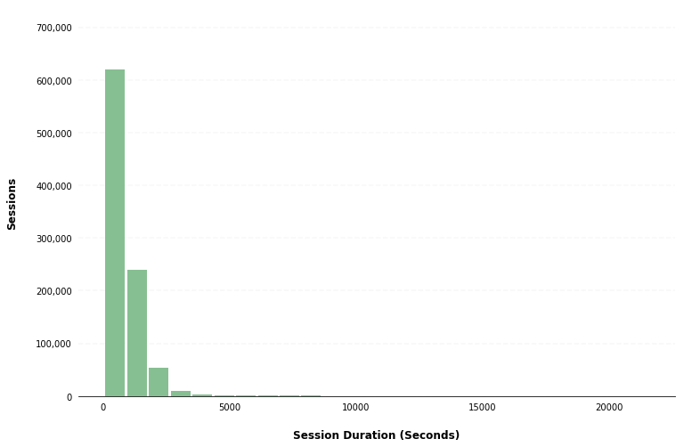

```python
ax = td_data.hist(column='tripduration', bins=25, grid=False, figsize=(12,8), color='#86bf91', zorder=2, rwidth=0.9)

ax = ax[0]
for x in ax:

    # Despine
    x.spines['right'].set_visible(False)
    x.spines['top'].set_visible(False)
    x.spines['left'].set_visible(False)

    # Switch off ticks
    x.tick_params(axis="both", which="both", bottom="off", top="off", labelbottom="on", left="off", right="off", labelleft="on")

    # Draw horizontal axis lines
    vals = x.get_yticks()
    for tick in vals:
        x.axhline(y=tick, linestyle='dashed', alpha=0.4, color='#eeeeee', zorder=1)

    # Remove title
    x.set_title("")

    # Set x-axis label
    x.set_xlabel("Session Duration (Seconds)", labelpad=20, weight='bold', size=12)

    # Set y-axis label
    x.set_ylabel("Sessions", labelpad=20, weight='bold', size=12)

    # Format y-axis label
    x.yaxis.set_major_formatter(StrMethodFormatter('{x:,g}'))
```

```python
age_labels = pd.read_csv("/Users/rebeccajbooth/Documents/newcitidata/agelabels.csv")
age_labels.head()
```

|  | birth_year | data_year | age | label |
| --- | --- | --- | --- | --- |
| 0 | 1899 | 2014 | 115 | supercentenarian |
| 1 | 1900 | 2014 | 114 | supercentenarian |
| 2 | 1901 | 2014 | 113 | supercentenarian |
| 3 | 1902 | 2014 | 112 | supercentenarian |
| 4 | 1903 | 2014 | 111 | supercentenarian |

```python
age_labels.dtypes
```

```
birth_year     int64
data_year      int64
age            int64
label         object
dtype: object
```

# Create the names for the the age groups